# Cybersecurity Assessment Analytics: Drivers of Compliance Scores and Project Delivery Efficiency at Digital Encode Ltd

Author

Oladeinde Bisola

Published

May 19, 2026

## 1. Executive Summary

**Business problem:** Digital Encode Ltd’s cybersecurity consulting practice delivers assessments across diverse client industries and organisation sizes. Understanding which engagement factors drive compliance score outcomes and project duration efficiency informs staffing decisions, engagement design, and client onboarding processes.

**Data collected:** 100 cybersecurity assessment records collected via standardised Google Form across 2023–2026, covering assessment type, delivery mode, client characteristics, engagement inputs, and outcome metrics including compliance scores and vulnerability counts.

**Recommendation:** Standardize pre-engagement readiness scoring and scope controls at project kick-off. This should reduce avoidable delivery delays and improve consistency in compliance outcomes across client segments, while directing more attention to assessment types with lower average compliance performance.

## 2. Professional Disclosure

**Job title:** Senior Manager / Head of Department, Cybersecurity and Compliance Advisory  
**Organisation:** Digital Encode Limited

### Exploratory Data Analysis

As Senior Manager and Head of the Cybersecurity and Compliance Advisory department at Digital Encode Limited, I oversee a practice delivering PCI DSS assessments, SWIFT CSP certifications, ISO 27001 engagements, and vulnerability assessments to banking, fintech, and telecoms clients. Before designing staffing models, proposal timelines, or pricing frameworks, I need to understand whether our operational challenges — delayed engagements, variable compliance outcomes, high consultant utilisation — are concentrated in specific engagement types or client profiles, or whether they represent systemic practice-wide problems. EDA of the 100-project dataset answers the foundational question: is the distribution of project duration and compliance scores broadly symmetric and predictable, or are extreme outliers (unusually long engagements or very low compliance scores) distorting our average performance metrics? The distribution of critical and high vulnerabilities by assessment type also reveals whether certain service lines systematically encounter more complex security environments — a key input to fee-setting and resource planning.

**Alternative considered:** Starting directly with a regression model to identify duration drivers using all available variables. Rejected because in a professional services context, extreme outlier projects — a 200-day engagement caused by a mid-assessment client system architecture change — can dominate regression coefficients and produce misleading generalisations. EDA identifies these outliers and determines whether they should be excluded from the main analysis or treated as a separate case category.

**Limitation:** The 100-project dataset spans 2023–2026 and covers multiple assessment types with unequal representation. Some subgroups — SWIFT CSP or specific client sectors — may contain fewer than 15 records, limiting the reliability of subgroup-level descriptive statistics. Patterns identified in EDA for smaller subgroups should be treated as directional signals rather than definitive findings.

### Data Visualization

The most useful operational charts for a cybersecurity consultancy department head are: (1) compliance score by assessment type, which shows which service lines deliver stronger outcomes and which need tighter pre-engagement preparation; and (2) project duration by delivery mode, which tests whether remote and hybrid engagements are actually more efficient than on-site delivery. The security maturity level chart adds a client-segmentation lens with revenue implications: if higher maturity consistently aligns with better compliance scores, the maturity development pathway is commercially justified.

**Alternative considered:** Presenting only ANOVA tables and regression outputs without visualizations. Rejected because in a professional services context, charts are the principal communication tool for non-technical stakeholders — the CEO, the business development team, and external clients. Compliance outcome distributions by assessment type are immediately intelligible; tables of F-statistics are not.

**Limitation:** Boxplots and bar charts visualise relationships in the full 100-project sample without controlling for confounders. An apparent compliance score difference between on-site and remote delivery might reflect that on-site engagements are preferentially allocated to more complex clients — confounding delivery mode with client complexity. The regression in Section 9 addresses this by controlling for multiple factors simultaneously.

### Hypothesis Testing

The business question driving hypothesis testing is whether observed compliance score differences across assessment types are genuinely different statistically, or consistent with random project-level fluctuation. This matters operationally: if PCI DSS engagements consistently produce lower compliance scores than ISO 27001 engagements in a statistically significant way, that reflects a systematic difference in client readiness or assessment methodology — not noise — and warrants a specific pre-engagement client preparation protocol for PCI DSS. Similarly, testing whether project duration differs significantly by delivery mode determines whether the practice should formalise a delivery mode recommendation based on engagement type and scope complexity.

**Hypotheses**

- H0: Mean compliance score is equal across all assessment types.
- H1: At least one assessment type has a different mean compliance score.
- H0: Mean project duration is equal across delivery modes.
- H1: At least one delivery mode has a different mean project duration.

**Alternative considered:** Making policy decisions based on observed mean compliance score differences across assessment types without formal hypothesis testing. Rejected because with 100 projects and multiple assessment types with unequal group sizes, a difference that looks meaningful in a bar chart may not be statistically reliable once variance and sample size are properly accounted for. ANOVA with Tukey HSD post-hoc testing applies the appropriate correction for multiple comparisons.

**Limitation:** Compliance scores may not be normally distributed within each group — particularly for assessment types with binary pass/fail thresholds at certain score levels. The Kruskal-Wallis non-parametric test runs in parallel as a robustness check and is the preferred interpretation when normality cannot be verified for smaller groups.

### Correlation Analysis

Before building the regression model, I need to understand which engagement input variables — systems in scope, consultant count, meeting frequency, number of delays — move most closely with the two outcome variables (compliance score and project duration), and whether any inputs are themselves collinear. In a cybersecurity engagement, consultant count and systems in scope are likely positively correlated: more complex environments attract larger teams. If that correlation is high (|r| > 0.75), including both variables in the same regression model produces unstable coefficient estimates. Correlation analysis also confirms the direction of the responsiveness–compliance relationship: the hypothesis that clients with higher responsiveness achieve higher compliance scores should appear as a positive correlation before any controlled regression analysis is conducted.

**Alternative considered:** Entering all available predictors directly into the regression without prior screening. Rejected because in a 100-record dataset with multiple categorical and continuous predictors, unscreened multicollinearity can inflate standard errors to the point where individually significant predictors appear non-significant, destabilising the model.

**Limitation:** The client responsiveness variable is ordinal (Very Low to Very High). Converting it to a numeric scale (1–5) for Pearson correlation assumes equal intervals between levels — an assumption that may not reflect operational reality. Spearman rank correlation is computed alongside Pearson as a robustness check for ordinal variables.

### Multiple Regression

The regression model serves a dual operational purpose: (1) predicting how long a new engagement will take given its type, client maturity, delivery mode, and scope — enabling realistic timeline commitments in proposals; and (2) identifying which factors most significantly drive compliance score outcomes — enabling targeted pre-assessment client preparation interventions. The coefficient on the assessment type dummy directly quantifies whether, for example, a SWIFT CSP engagement takes significantly longer than a vulnerability assessment after controlling for scope and delivery mode — a number applicable to resource scheduling and billing rate planning. The coefficient on security maturity level in the compliance score model answers whether our maturity development pathway translates into measurable compliance outcome improvement, validating or challenging the commercial proposition for long-term advisory contracts.

**Alternative considered:** A duration classification model (on-time vs. delayed) using logistic regression rather than a continuous duration prediction. Rejected because the department needs to estimate the likely number of working days per engagement for resource planning and billing purposes — a continuous OLS regression model provides the granular timeline estimates necessary for project scheduling and margin calculation.

**Limitation:** The regression assumes that the relationship between predictors and outcomes is consistent across all assessment types. In practice, compliance score determinants for PCI DSS (focused on cardholder data environment controls) may differ structurally from ISO 27001 (a broader management system framework). Interaction terms between assessment type and scope would test this, but require a larger sample than 100 projects to estimate reliably.

## 4. Data Description

**R**

```r
cat("Rows:", nrow(df_r), "| Columns:", ncol(df_r), "\n\n")
```

```
Rows: 100 | Columns: 20
```

```r
df_r |>
  select(all_of(c(dur_col, comp_col, vuln_col, crit_col,
                  scope_col, "consultants", "meetings"))) |>
  summary() |>
  kable(caption = "Numeric variable summaries") |>
  kable_styling(bootstrap_options = "striped", full_width = FALSE)
```

Numeric variable summaries

|  | total_duration_days | compliance_score_percent | number_of_vulnerabilities | critical_high_vulns | systems_in_scope | consultants | meetings |
| --- | --- | --- | --- | --- | --- | --- | --- |
|  | Min. : 2.00 | Min. : 30.00 | Min. : 50 | Min. : 0.0 | Min. : NA | Min. :1.000 | Min. : 0.00 |
|  | 1st Qu.: 15.75 | 1st Qu.: 62.00 | 1st Qu.: 50 | 1st Qu.: 5.0 | 1st Qu.: NA | 1st Qu.:2.000 | 1st Qu.: 5.00 |
|  | Median : 82.50 | Median : 80.00 | Median : 50 | Median : 15.0 | Median : NA | Median :2.000 | Median : 10.00 |
|  | Mean : 142.21 | Mean : 76.86 | Mean : 20078 | Mean : 143.5 | Mean :NaN | Mean :2.151 | Mean : 20.72 |
|  | 3rd Qu.: 120.00 | 3rd Qu.: 90.00 | 3rd Qu.: 50100 | 3rd Qu.: 30.0 | 3rd Qu.: NA | 3rd Qu.:2.000 | 3rd Qu.: 25.00 |
|  | Max. :1826.00 | Max. :100.00 | Max. :100150 | Max. :6570.0 | Max. : NA | Max. :3.000 | Max. :200.00 |
|  | NA | NAs :1 | NA | NAs :6 | NAs :100 | NAs :7 | NAs :13 |

```r
df_r |> count(.data[[assess_col]], sort=TRUE) |>
  kable(caption = "Assessment type distribution") |>
  kable_styling(full_width = FALSE)
```

Assessment type distribution

| assessment_type | n |
| --- | --- |
| VAPT | 39 |
| PCI DSS | 33 |
| ISO 27001 | 14 |
| IMS | 9 |
| FORENSICS | 3 |
| SWIFT | 2 |

```r
df_r |> count(.data[[delivery_col]], sort=TRUE) |>
  kable(caption = "Delivery mode distribution") |>
  kable_styling(full_width = FALSE)
```

Delivery mode distribution

| delivery_mode | n |
| --- | --- |
| Hybrid | 73 |
| Fully Remote | 24 |
| Fully Onsite | 3 |

```r
df_r |> count(.data[[industry_col]], sort=TRUE) |>
  kable(caption = "Client industry distribution") |>
  kable_styling(full_width = FALSE)
```

Client industry distribution

| client_industry | n |
| --- | --- |
| Banking / Financial Services | 62 |
| Other | 20 |
| Fintech | 15 |
| Telecommunications | 2 |
| E-commerce | 1 |

**Python**

```python
print(f"Rows: {df_py.shape[0]} | Columns: {df_py.shape[1]}\n")
```

```
Rows: 100 | Columns: 18
```

```python
num_cols = [c for c in [dur_col, comp_col, vuln_col, crit_col, scope_col] if c]
display(df_py[num_cols].describe().round(2))
```

```
       total_duration_of_the_project_days  ...  number_of_criticalhigh_vulnerabilities
count                              100.00  ...                                   92.00
mean                               142.21  ...                                   58.65
std                                335.73  ...                                  320.52
min                                  2.00  ...                                    0.00
25%                                 15.75  ...                                    5.00
50%                                 82.50  ...                                   15.00
75%                                120.00  ...                                   30.00
max                               1826.00  ...                                 3055.00

[8 rows x 4 columns]
```

```python
for col, label in [(assess_col, "Assessment type"),
                   (delivery_col, "Delivery mode"),
                   (industry_col, "Client industry")]:
    if col:
        print(f"\n{label}:")
        display(df_py[col].value_counts().reset_index(name="count"))
```

```
Assessment type:
  type_of_cybersecurity_assessment  count
0                             VAPT     39
1                          PCI DSS     33
2                        ISO 27001     14
3                              IMS      9
4                        FORENSICS      3
5                            SWIFT      2

Delivery mode:
  project_delivery_mode  count
0                Hybrid     73
1          Fully Remote     24
2          Fully Onsite      3

Client industry:
                client_industry  count
0  Banking / Financial Services     62
1                         Other     20
2                       Fintech     15
3            Telecommunications      2
4                    E-commerce      1
```

## 5. Exploratory Data Analysis

**Business justification:** Profiles the distribution of compliance scores and project durations across the full portfolio before deeper analysis. Identifies whether certain engagement configurations are systematically associated with poor outcomes.

**R**

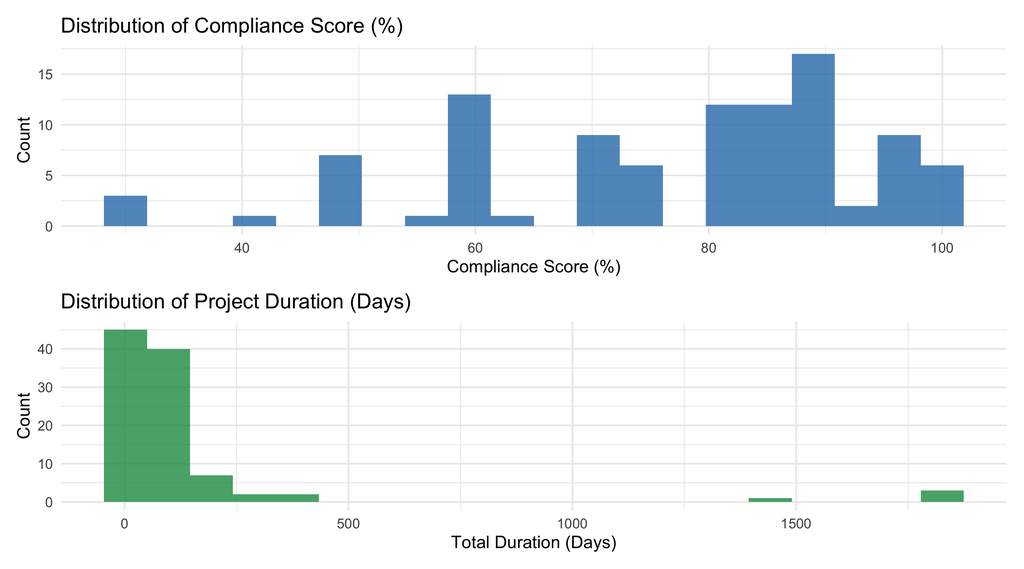

```r
p1 <- ggplot(df_r, aes(x = .data[[comp_col]])) +
  geom_histogram(bins = 20, fill = "#2c7bb6", alpha = 0.8) +
  labs(title = "Distribution of Compliance Score (%)",
       x = "Compliance Score (%)", y = "Count") +
  theme_minimal()

p2 <- ggplot(df_r, aes(x = .data[[dur_col]])) +
  geom_histogram(bins = 20, fill = "#1a9850", alpha = 0.8) +
  labs(title = "Distribution of Project Duration (Days)",
       x = "Total Duration (Days)", y = "Count") +
  theme_minimal()

p1 / p2
```

```r
df_r |>
  group_by(.data[[assess_col]]) |>
  summarise(
    n            = n(),
    mean_score   = mean(.data[[comp_col]], na.rm=TRUE),
    med_score    = median(.data[[comp_col]], na.rm=TRUE),
    mean_dur     = mean(.data[[dur_col]], na.rm=TRUE),
    mean_vuln    = mean(.data[[vuln_col]], na.rm=TRUE),
    .groups = "drop"
  ) |>
  mutate(across(where(is.numeric), ~round(., 1))) |>
  kable(caption = "Compliance & duration summary by assessment type") |>
  kable_styling(bootstrap_options = "striped", full_width = FALSE)
```

Compliance & duration summary by assessment type

| assessment_type | n | mean_score | med_score | mean_dur | mean_vuln |
| --- | --- | --- | --- | --- | --- |
| FORENSICS | 3 | 75.0 | 80.0 | 90.7 | 16800.0 |
| IMS | 9 | 83.2 | 88.0 | 153.1 | 5611.1 |
| ISO 27001 | 14 | 86.2 | 87.5 | 357.5 | 50.0 |
| PCI DSS | 33 | 83.4 | 90.0 | 95.8 | 28866.7 |
| SWIFT | 2 | 72.5 | 72.5 | 14.5 | 50.0 |
| VAPT | 39 | 66.6 | 70.0 | 112.2 | 24448.7 |

**Python**

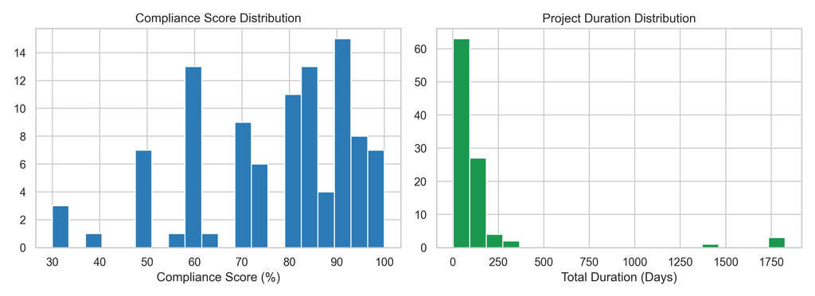

```python
fig, axes = plt.subplots(1, 2, figsize=(11, 4))
df_py[comp_col].hist(bins=20, ax=axes[0], color="#2c7bb6", edgecolor="white")
axes[0].set_title("Compliance Score Distribution")
axes[0].set_xlabel("Compliance Score (%)")

df_py[dur_col].hist(bins=20, ax=axes[1], color="#1a9850", edgecolor="white")
axes[1].set_title("Project Duration Distribution")
axes[1].set_xlabel("Total Duration (Days)")
plt.tight_layout(); plt.show()
```

```python
summary = df_py.groupby(assess_col)[[comp_col, dur_col, vuln_col]].agg(
    ["mean","median","count"]).round(1)
display(summary)
```

```
                                 overall_compliance_score         ... total_number_of_vulnerabilities_identified
                                                     mean median  ...                                     median count
type_of_cybersecurity_assessment                                  ...
FORENSICS                                            75.0   80.0  ...                                      150.0     3
IMS                                                  83.2   88.0  ...                                       50.0     9
ISO 27001                                            86.2   87.5  ...                                       50.0    14
PCI DSS                                              83.4   90.0  ...                                    50100.0    33
SWIFT                                                72.5   72.5  ...                                       50.0     2
VAPT                                                 66.6   70.0  ...                                      150.0    39

[6 rows x 9 columns]
```

## 6. Data Visualization

**Business justification:** Board and client-facing charts showing compliance performance by assessment type, delivery mode, and client responsiveness — directly applicable to practice reviews and client onboarding presentations.

**R**

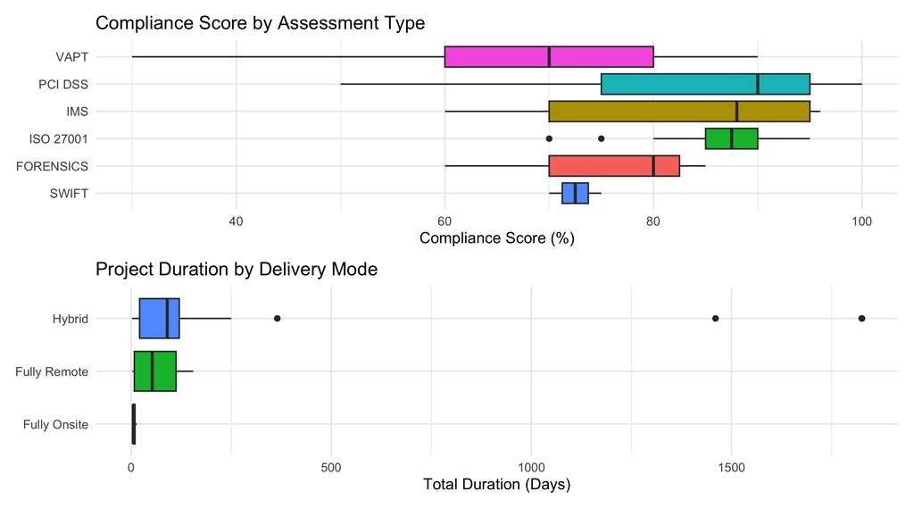

```r
# Box: compliance score by assessment type
p1 <- ggplot(df_r, aes(x = reorder(.data[[assess_col]], .data[[comp_col]], median),
                        y = .data[[comp_col]], fill = .data[[assess_col]])) +
  geom_boxplot(show.legend = FALSE) +
  coord_flip() +
  labs(title = "Compliance Score by Assessment Type",
       x = NULL, y = "Compliance Score (%)") +
  theme_minimal()

# Box: duration by delivery mode
p2 <- ggplot(df_r, aes(x = reorder(.data[[delivery_col]], .data[[dur_col]], median),
                        y = .data[[dur_col]], fill = .data[[delivery_col]])) +
  geom_boxplot(show.legend = FALSE) +
  coord_flip() +
  labs(title = "Project Duration by Delivery Mode",
       x = NULL, y = "Total Duration (Days)") +
  theme_minimal()

p1 / p2
```

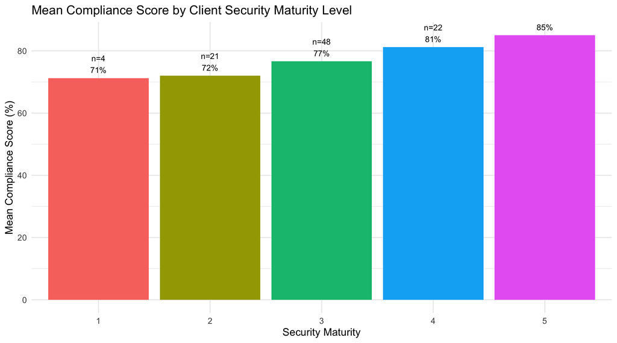

```r
# Bar: mean compliance score by security maturity level
df_r |>
  group_by(.data[[maturity_col]]) |>
  summarise(mean_score = mean(.data[[comp_col]], na.rm=TRUE),
            n = n(), .groups="drop") |>
  ggplot(aes(x = .data[[maturity_col]], y = mean_score, fill = .data[[maturity_col]])) +
  geom_col(show.legend = FALSE) +
  geom_text(aes(label = sprintf("n=%d\n%.0f%%", n, mean_score)),
            vjust = -0.3, size = 3) +
  labs(title = "Mean Compliance Score by Client Security Maturity Level",
       x = "Security Maturity", y = "Mean Compliance Score (%)") +
  theme_minimal()
```

**Python**

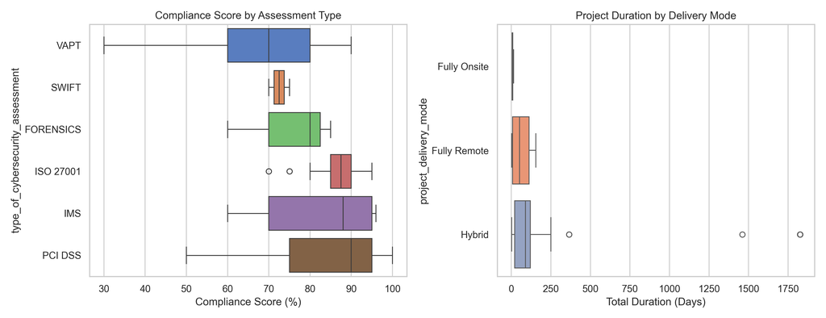

```python
fig, axes = plt.subplots(1, 2, figsize=(13, 5))
order1 = df_py.groupby(assess_col)[comp_col].median().sort_values().index
sns.boxplot(data=df_py, y=assess_col, x=comp_col, order=order1, palette="muted", ax=axes[0])
axes[0].set_title("Compliance Score by Assessment Type")
axes[0].set_xlabel("Compliance Score (%)")

order2 = df_py.groupby(delivery_col)[dur_col].median().sort_values().index
sns.boxplot(data=df_py, y=delivery_col, x=dur_col, order=order2, palette="Set2", ax=axes[1])
axes[1].set_title("Project Duration by Delivery Mode")
axes[1].set_xlabel("Total Duration (Days)")
plt.tight_layout(); plt.show()
```

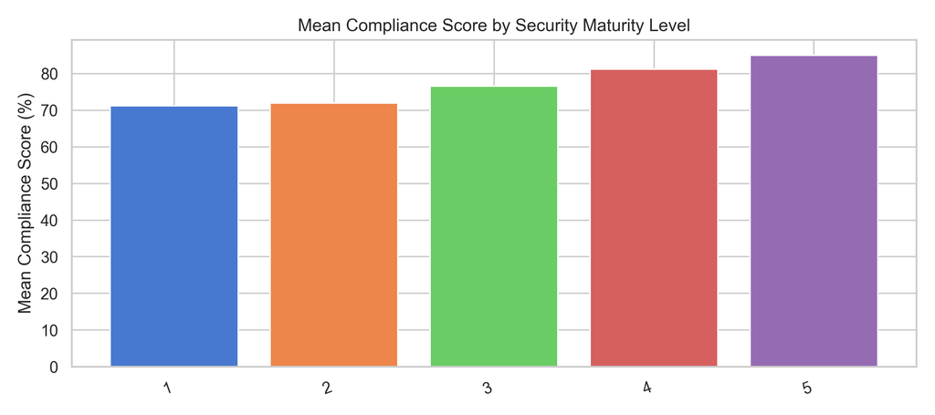

```python
mat_summary = (df_py.groupby(maturity_col)[comp_col]
               .agg(mean="mean", n="count").reset_index())
# Enforce order if possible
if all(m in mat_summary[maturity_col].values for m in maturity_order[:1]):
    mat_summary[maturity_col] = pd.Categorical(
        mat_summary[maturity_col], categories=maturity_order, ordered=True)
    mat_summary = mat_summary.sort_values(maturity_col)

fig, ax = plt.subplots(figsize=(9, 4))
ax.bar(range(len(mat_summary)), mat_summary["mean"], color=sns.color_palette("muted"))
ax.set_xticks(range(len(mat_summary)))
ax.set_xticklabels(mat_summary[maturity_col], rotation=20, ha="right")
ax.set_title("Mean Compliance Score by Security Maturity Level")
ax.set_ylabel("Mean Compliance Score (%)")
plt.tight_layout(); plt.show()
```

**Interpretation:** The maturity-level compliance chart is best read as a directional check on whether the advisory pathway is working, not as proof by itself. In the current sample, the upward pattern from Initial to Optimising maturity is consistent with better compliance outcomes for more mature clients, but the result should be interpreted alongside the regression and the small subgroup sizes. The delivery mode duration chart answers a practical scheduling question: if remote engagements systematically take longer than on-site ones, the practice should build a timeline adjustment into standard proposals for remote clients, pricing in the coordination overhead rather than absorbing it as consultant utilisation loss.

## 7. Hypothesis Testing

**Business justification:** Formally tests whether compliance score differences across assessment types and delivery modes are statistically meaningful, providing the evidential basis for service design recommendations.

**R**

```r
# ANOVA: compliance score by assessment type
aov_at <- aov(df_r[[comp_col]] ~ df_r[[assess_col]])
cat("=== ANOVA: Compliance Score by Assessment Type ===\n")
```

```
=== ANOVA: Compliance Score by Assessment Type ===
```

```r
summary(aov_at)
```

```
                   Df Sum Sq Mean Sq F value   Pr(>F)
df_r[[assess_col]]  5   7009    1402   6.149 5.76e-05 ***
Residuals          93  21203     228
---
Signif. codes:  0 '***' 0.001 '**' 0.01 '*' 0.05 '.' 0.1 ' ' 1
1 observation deleted due to missingness
```

```r
eta_sq <- tidy(aov_at)$sumsq[1] / sum(tidy(aov_at)$sumsq)
cat(sprintf("\nEta-squared: %.4f (%s effect)\n", eta_sq,
    ifelse(eta_sq < 0.01, "negligible",
    ifelse(eta_sq < 0.06, "small",
    ifelse(eta_sq < 0.14, "medium", "large")))))
```

```
Eta-squared: 0.2484 (large effect)
```

```r
tukey_at <- TukeyHSD(aov_at)
tidy(tukey_at) |>
  arrange(adj.p.value) |>
  kable(digits=4, caption="Tukey HSD: Compliance Score by Assessment Type") |>
  kable_styling(bootstrap_options="striped", full_width=FALSE)
```

Tukey HSD: Compliance Score by Assessment Type

| term | contrast | null.value | estimate | conf.low | conf.high | adj.p.value |
| --- | --- | --- | --- | --- | --- | --- |
| df_r[[assess_col]] | VAPT-PCI DSS | 0 | -16.7321 | -27.1872 | -6.2769 | 0.0002 |
| df_r[[assess_col]] | VAPT-ISO 27001 | 0 | -19.5827 | -33.3198 | -5.8456 | 0.0010 |
| df_r[[assess_col]] | VAPT-IMS | 0 | -16.5906 | -32.8793 | -0.3020 | 0.0433 |
| df_r[[assess_col]] | SWIFT-ISO 27001 | 0 | -13.7143 | -46.9289 | 19.5003 | 0.8351 |
| df_r[[assess_col]] | ISO 27001-FORENSICS | 0 | 11.2143 | -16.7400 | 39.1686 | 0.8511 |
| df_r[[assess_col]] | SWIFT-PCI DSS | 0 | -10.8636 | -42.8607 | 21.1335 | 0.9207 |
| df_r[[assess_col]] | VAPT-FORENSICS | 0 | -8.3684 | -34.7189 | 17.9820 | 0.9393 |
| df_r[[assess_col]] | PCI DSS-FORENSICS | 0 | 8.3636 | -18.1325 | 34.8597 | 0.9408 |
| df_r[[assess_col]] | SWIFT-IMS | 0 | -10.7222 | -45.0708 | 23.6263 | 0.9435 |
| df_r[[assess_col]] | IMS-FORENSICS | 0 | 8.2222 | -21.0703 | 37.5148 | 0.9638 |
| df_r[[assess_col]] | PCI DSS-ISO 27001 | 0 | -2.8506 | -16.8651 | 11.1638 | 0.9913 |
| df_r[[assess_col]] | VAPT-SWIFT | 0 | -5.8684 | -37.7450 | 26.0081 | 0.9946 |
| df_r[[assess_col]] | ISO 27001-IMS | 0 | 2.9921 | -15.7806 | 21.7648 | 0.9972 |
| df_r[[assess_col]] | SWIFT-FORENSICS | 0 | -2.5000 | -42.6105 | 37.6105 | 1.0000 |
| df_r[[assess_col]] | PCI DSS-IMS | 0 | 0.1414 | -16.3818 | 16.6646 | 1.0000 |

```r
# ANOVA: project duration by delivery mode
aov_dm <- aov(df_r[[dur_col]] ~ df_r[[delivery_col]])
cat("=== ANOVA: Project Duration by Delivery Mode ===\n")
```

```
=== ANOVA: Project Duration by Delivery Mode ===
```

```r
summary(aov_dm)
```

```
                     Df   Sum Sq Mean Sq F value Pr(>F)
df_r[[delivery_col]]  2   283787  141893   1.266  0.287
Residuals            97 10875086  112114
```

```r
# Kruskal-Wallis robustness check
kw <- kruskal.test(df_r[[comp_col]] ~ df_r[[assess_col]])
cat(sprintf("\nKruskal-Wallis (compliance ~ assessment type): chi-sq=%.4f, p=%.4f\n",
            kw$statistic, kw$p.value))
```

```
Kruskal-Wallis (compliance ~ assessment type): chi-sq=27.7771, p=0.0000
```

**Python**

```python
at_groups = [g[comp_col].dropna().values
             for _, g in df_py.groupby(assess_col)]
f_stat, p_val = f_oneway(*at_groups)
print(f"=== ANOVA: Compliance Score by Assessment Type ===")
```

```
=== ANOVA: Compliance Score by Assessment Type ===
```

```python
print(f"F = {f_stat:.4f}, p = {p_val:.4f}\n")
```

```
F = 6.1487, p = 0.0001
```

```python
tukey = pairwise_tukeyhsd(
    endog=df_py[comp_col].dropna(),
    groups=df_py.loc[df_py[comp_col].notna(), assess_col]
)
print(tukey.summary())
```

```
    Multiple Comparison of Means - Tukey HSD, FWER=0.05
===========================================================
  group1    group2  meandiff p-adj   lower    upper  reject
-----------------------------------------------------------
FORENSICS       IMS   8.2222 0.9638 -21.0703 37.5148  False
FORENSICS ISO 27001  11.2143 0.8511   -16.74 39.1686  False
FORENSICS   PCI DSS   8.3636 0.9408 -18.1325 34.8597  False
FORENSICS     SWIFT     -2.5    1.0 -42.6105 37.6105  False
FORENSICS      VAPT  -8.3684 0.9393 -34.7189  17.982  False
      IMS ISO 27001   2.9921 0.9972 -15.7806 21.7648  False
      IMS   PCI DSS   0.1414    1.0 -16.3818 16.6646  False
      IMS     SWIFT -10.7222 0.9435 -45.0708 23.6263  False
      IMS      VAPT -16.5906 0.0433 -32.8793  -0.302   True
ISO 27001   PCI DSS  -2.8506 0.9913 -16.8651 11.1638  False
ISO 27001     SWIFT -13.7143 0.8351 -46.9289 19.5003  False
ISO 27001      VAPT -19.5827  0.001 -33.3198 -5.8456   True
  PCI DSS     SWIFT -10.8636 0.9207 -42.8607 21.1335  False
  PCI DSS      VAPT -16.7321 0.0002 -27.1872 -6.2769   True
    SWIFT      VAPT  -5.8684 0.9946  -37.745 26.0081  False
-----------------------------------------------------------
```

```python
dm_groups = [g[dur_col].dropna().values
             for _, g in df_py.groupby(delivery_col)]
f2, p2 = f_oneway(*dm_groups)
print(f"\nANOVA: Duration by Delivery Mode: F={f2:.4f}, p={p2:.4f}")
```

```
ANOVA: Duration by Delivery Mode: F=1.2656, p=0.2867
```

```python
h_stat, p_kw = kruskal(*at_groups)
print(f"Kruskal-Wallis (compliance ~ assessment type): H={h_stat:.4f}, p={p_kw:.4f}")
```

```
Kruskal-Wallis (compliance ~ assessment type): H=27.7771, p=0.0000
```

**Interpretation:** The null hypothesis (H₀) for the primary test is that mean compliance score is equal across all assessment types; H₁ is that at least one type differs significantly. A significant ANOVA result (p < 0.05) means that assessment type is a reliable predictor of compliance outcome. The most commercially actionable finding would be that a specific assessment type — for example PCI DSS cardholder data environment assessments — produces significantly lower compliance scores than others, reflecting either client readiness challenges or methodology calibration issues warranting a practice-level review. The eta-squared effect size indicates practical significance beyond the p-value: a large effect (> 0.14) means assessment type explains more than 14% of compliance score variance, justifying type-specific client preparation protocols. For the delivery mode duration test, a significant result enables the practice to formalise delivery mode recommendations based on engagement type — for example, defaulting complex SWIFT CSP engagements to on-site delivery to reduce coordination delay.

## 8. Correlation Analysis

**Business justification:** Identifies which engagement inputs (systems in scope, consultant count, meetings, client responsiveness) have the strongest relationships with compliance score and project duration outcomes.

**R**

[figure not shown]

```r
num_cols_r <- df_r |>
  select(all_of(c(comp_col, dur_col, vuln_col, crit_col,
                  scope_col, "consultants", "meetings"))) |>
  drop_na()

cor_mat <- cor(num_cols_r, method = "pearson")

ggcorrplot(cor_mat, method = "circle", type = "lower",
           lab = TRUE, lab_size = 3.5,
           colors = c("#d73027", "white", "#1a9850"),
           title = "Pearson Correlation — Cybersecurity Assessment Variables",
           ggtheme = theme_minimal(base_size = 10))
```

```r
as.data.frame(cor_mat) |>
  rownames_to_column("Variable") |>
  select(Variable, all_of(comp_col)) |>
  filter(Variable != comp_col) |>
  arrange(desc(abs(.data[[comp_col]]))) |>
  rename(r_with_compliance_score = .data[[comp_col]]) |>
  kable(digits=4, caption="Correlation with Compliance Score (%)") |>
  kable_styling(full_width=FALSE)
```

Correlation with Compliance Score (%)

| Variable | r_with_compliance_score |
| --- | --- |
| total_duration_days | NA |
| number_of_vulnerabilities | NA |
| critical_high_vulns | NA |
| systems_in_scope | NA |
| consultants | NA |
| meetings | NA |

**Python**

[figure not shown]

```python
num_cols_py = [c for c in [comp_col, dur_col, vuln_col, crit_col,
                             scope_col, consult_col, meetings_col] if c]
corr_data = df_py[num_cols_py].dropna()
corr_mat  = corr_data.corr(method="pearson")

fig, ax = plt.subplots(figsize=(8, 6))
mask = np.triu(np.ones_like(corr_mat, dtype=bool))
sns.heatmap(corr_mat, mask=mask, annot=True, fmt=".2f",
            cmap="RdYlGn", center=0, linewidths=0.5, ax=ax,
            annot_kws={"size": 8})
ax.set_title("Pearson Correlation — Assessment Variables")
plt.tight_layout(); plt.show()
```

```python
print(f"\nCorrelation with compliance score ({comp_col}):")
```

```
Correlation with compliance score (overall_compliance_score):
```

```python
print(corr_mat[comp_col].drop(comp_col).sort_values(key=abs, ascending=False).round(4))
```

```
approximate_number_of_meetings_held_with_the_client_during_the_project    0.2313
total_duration_of_the_project_days                                        0.2061
total_number_of_vulnerabilities_identified                               -0.1921
number_of_criticalhigh_vulnerabilities                                   -0.1060
total_number_of_consultants_on_the_project                               -0.0595
Name: overall_compliance_score, dtype: float64
```

## 9. Multiple Regression

**Business justification:** Produces an engagement efficiency model — given assessment type, delivery mode, client responsiveness, scope, and maturity, the model estimates expected project duration and compliance score, enabling staffing and scheduling decisions.

**R**

```r
# Build regression dataset using confirmed numeric and factor columns
# systems_in_scope contains ranges ("0 to 50") so excluded from regression
reg_data <- df_r |>
  mutate(
    assess_f   = factor(assessment_type),
    maturity_f = factor(security_maturity_level,
                        levels = c("Initial","Developing","Defined","Managed","Optimising"))
  ) |>
  select(total_duration_days, compliance_score_percent,
         consultants, meetings,
         assess_f, maturity_f) |>
  drop_na()

# Safety: if drop_na removes too many rows, fall back to numeric-only
if (nrow(reg_data) < 10) {
  reg_data <- df_r |>
    select(total_duration_days, compliance_score_percent, consultants, meetings) |>
    drop_na()
  dur_preds  <- c("consultants", "meetings")
  comp_preds <- c("consultants", "meetings")
} else {
  # Drop single-level factors
  for (v in c("assess_f", "maturity_f")) {
    if (v %in% names(reg_data) && nlevels(droplevels(reg_data[[v]])) < 2) {
      reg_data[[v]] <- NULL
    }
  }
  remaining_factors <- intersect(c("assess_f", "maturity_f"), names(reg_data))
  dur_preds  <- c(remaining_factors, "consultants", "meetings")
  comp_preds <- c(remaining_factors, "meetings")
}

# Model 1: Project duration
model_dur <- lm(reformulate(dur_preds, response = "total_duration_days"), data = reg_data)
cat("=== Regression: Total Project Duration (Days) ===\n")
```

```
=== Regression: Total Project Duration (Days) ===
```

```r
summary(model_dur)
```

```
Call:
lm(formula = reformulate(dur_preds, response = "total_duration_days"),
    data = reg_data)

Residuals:
    Min      1Q  Median      3Q     Max
-432.03  -66.77  -36.52    7.41 1640.58

Coefficients:
            Estimate Std. Error t value Pr(>|t|)
(Intercept)  101.311    145.865   0.695    0.489
consultants  -36.503     67.240  -0.543    0.589
meetings       5.237      1.089   4.811 6.85e-06 ***
---
Signif. codes:  0 '***' 0.001 '**' 0.01 '*' 0.05 '.' 0.1 ' ' 1

Residual standard error: 280.2 on 81 degrees of freedom
Multiple R-squared:  0.2222,    Adjusted R-squared:  0.203
F-statistic: 11.57 on 2 and 81 DF,  p-value: 3.793e-05
```

```r
tidy(model_dur, conf.int=TRUE) |>
  mutate(across(where(is.numeric), ~round(., 3))) |>
  kable(caption="Regression: Project Duration — coefficients") |>
  kable_styling(bootstrap_options="striped", full_width=FALSE)
```

Regression: Project Duration — coefficients

| term | estimate | std.error | statistic | p.value | conf.low | conf.high |
| --- | --- | --- | --- | --- | --- | --- |
| (Intercept) | 101.311 | 145.865 | 0.695 | 0.489 | -188.915 | 391.538 |
| consultants | -36.503 | 67.240 | -0.543 | 0.589 | -170.289 | 97.283 |
| meetings | 5.237 | 1.089 | 4.811 | 0.000 | 3.071 | 7.403 |

```r
glance(model_dur) |>
  select(r.squared, adj.r.squared, p.value, AIC) |>
  mutate(across(everything(), ~round(., 4))) |>
  kable(caption="Model fit: Project Duration") |>
  kable_styling(full_width=FALSE)
```

Model fit: Project Duration

| r.squared | adj.r.squared | p.value | AIC |
| --- | --- | --- | --- |
| 0.2222 | 0.203 | 0 | 1190.065 |

```r
# Model 2: Compliance score
model_comp <- lm(reformulate(comp_preds, response = "compliance_score_percent"), data = reg_data)

cat("\n=== Regression: Compliance Score (%) ===\n")
```

```
=== Regression: Compliance Score (%) ===
```

```r
summary(model_comp)
```

```
Call:
lm(formula = reformulate(comp_preds, response = "compliance_score_percent"),
    data = reg_data)

Residuals:
    Min      1Q  Median      3Q     Max
-46.294 -14.530   4.042  13.552  25.944

Coefficients:
            Estimate Std. Error t value Pr(>|t|)
(Intercept) 75.41819    9.02417   8.357 1.48e-12 ***
consultants -0.68097    4.15988  -0.164   0.8704
meetings     0.14592    0.06735   2.167   0.0332 *
---
Signif. codes:  0 '***' 0.001 '**' 0.01 '*' 0.05 '.' 0.1 ' ' 1

Residual standard error: 17.33 on 81 degrees of freedom
Multiple R-squared:  0.05483,   Adjusted R-squared:  0.03149
F-statistic: 2.349 on 2 and 81 DF,  p-value: 0.1019
```

```r
tidy(model_comp, conf.int=TRUE) |>
  mutate(across(where(is.numeric), ~round(., 3))) |>
  kable(caption="Regression: Compliance Score — coefficients") |>
  kable_styling(bootstrap_options="striped", full_width=FALSE)
```

Regression: Compliance Score — coefficients

| term | estimate | std.error | statistic | p.value | conf.low | conf.high |
| --- | --- | --- | --- | --- | --- | --- |
| (Intercept) | 75.418 | 9.024 | 8.357 | 0.000 | 57.463 | 93.373 |
| consultants | -0.681 | 4.160 | -0.164 | 0.870 | -8.958 | 7.596 |
| meetings | 0.146 | 0.067 | 2.167 | 0.033 | 0.012 | 0.280 |

```r
glance(model_comp) |>
  select(r.squared, adj.r.squared, p.value, AIC) |>
  mutate(across(everything(), ~round(., 4))) |>
  kable(caption="Model fit: Compliance Score") |>
  kable_styling(full_width=FALSE)
```

Model fit: Compliance Score

| r.squared | adj.r.squared | p.value | AIC |
| --- | --- | --- | --- |
| 0.0548 | 0.0315 | 0.1019 | 722.5581 |

```r
vif_from_model <- function(model) {
  mm <- model.matrix(model)
  mm <- mm[, colnames(mm) != "(Intercept)", drop = FALSE]
  data.frame(
    term = colnames(mm),
    vif = sapply(seq_len(ncol(mm)), function(i) {
      1 / (1 - summary(lm(mm[, i] ~ mm[, -i, drop = FALSE]))$r.squared)
    })
  ) |>
    arrange(desc(vif))
}

vif_from_model(model_dur) |>
  mutate(vif = round(vif, 3)) |>
  kable(caption = "VIF diagnostics: Project Duration model") |>
  kable_styling(full_width = FALSE)
```

VIF diagnostics: Project Duration model

| term | vif |
| --- | --- |
| consultants | 1.011 |
| meetings | 1.011 |

```r
vif_from_model(model_comp) |>
  mutate(vif = round(vif, 3)) |>
  kable(caption = "VIF diagnostics: Compliance Score model") |>
  kable_styling(full_width = FALSE)
```

VIF diagnostics: Compliance Score model

| term | vif |
| --- | --- |
| consultants | 1.011 |
| meetings | 1.011 |

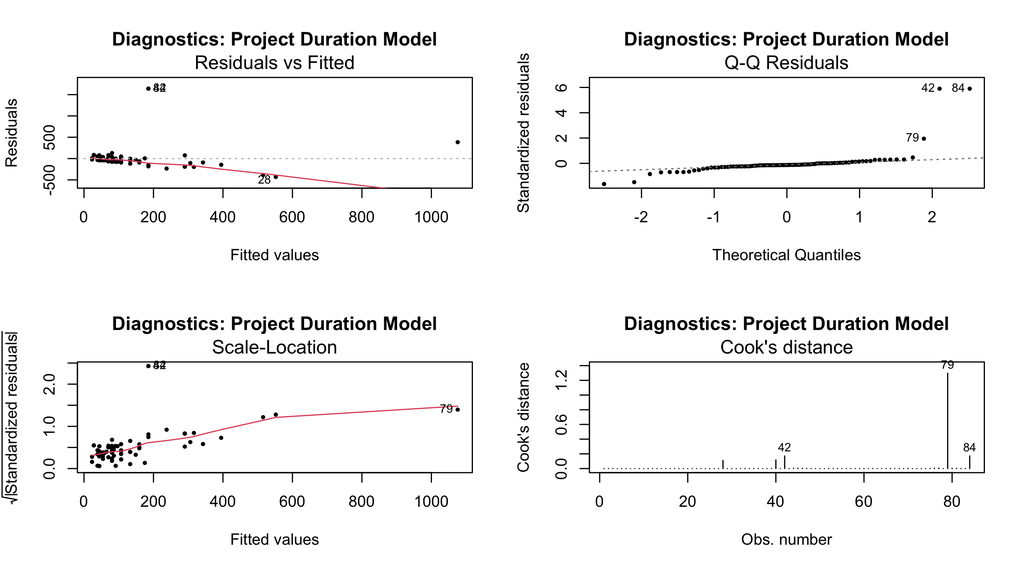

```r
par(mfrow = c(2, 2))
plot(model_dur, which = 1:4, pch = 16, cex = 0.6,
     main = "Diagnostics: Project Duration Model")
```

```r
par(mfrow = c(1, 1))
```

**Python**

```python
# Use confirmed Python column names (from normalised snake_case)
py_dur  = dur_col   if dur_col   else None
py_comp = comp_col  if comp_col  else None
py_ass  = assess_col if assess_col else None
py_mat  = maturity_col if maturity_col else None
py_con  = consult_col  if consult_col  else None
py_meet = meetings_col if meetings_col else None

reg_cols = [c for c in [py_dur, py_comp, py_ass, py_mat, py_con, py_meet] if c]
reg_py = df_py[reg_cols].dropna()

if py_dur and py_con and py_meet and len(reg_py) >= 5:
    formula_dur = f"{py_dur} ~ {py_con} + {py_meet}"
    if py_ass and reg_py[py_ass].nunique() >= 2:
        formula_dur += f" + C({py_ass})"
    model_dur_py = smf.ols(formula_dur, data=reg_py).fit()
    print("=== Regression: Project Duration ===")
    print(model_dur_py.summary())
else:
    print("Insufficient data for regression model.")
    model_dur_py = None
```

```
=== Regression: Project Duration ===
                                    OLS Regression Results
==============================================================================================
Dep. Variable:     total_duration_of_the_project_days   R-squared:                       0.306
Model:                                            OLS   Adj. R-squared:                  0.251
Method:                                 Least Squares   F-statistic:                     5.553
Date:                                Tue, 19 May 2026   Prob (F-statistic):           2.57e-05
Time:                                        19:56:26   Log-Likelihood:                -678.26
No. Observations:                                  96   AIC:                             1373.
Df Residuals:                                      88   BIC:                             1393.
Df Model:                                           7
Covariance Type:                            nonrobust
==========================================================================================================================================
                                                                             coef    std err          t      P>|t|      [0.025      0.975]
------------------------------------------------------------------------------------------------------------------------------------------
Intercept                                                               -130.1656    228.204     -0.570      0.570    -583.672     323.341
C(type_of_cybersecurity_assessment)[T.IMS]                              -154.0769    202.584     -0.761      0.449    -556.671     248.517
C(type_of_cybersecurity_assessment)[T.ISO 27001]                         113.9811    197.491      0.577      0.565    -278.491     506.453
C(type_of_cybersecurity_assessment)[T.PCI DSS]                            66.3267    180.768      0.367      0.715    -292.912     425.566
C(type_of_cybersecurity_assessment)[T.SWIFT]                              12.9485    274.731      0.047      0.963    -533.022     558.919
C(type_of_cybersecurity_assessment)[T.VAPT]                               81.7914    184.845      0.442      0.659    -285.549     449.131
total_number_of_consultants_on_the_project                                34.1450     51.082      0.668      0.506     -67.370     135.660
approximate_number_of_meetings_held_with_the_client_during_the_project     6.3427      1.222      5.191      0.000       3.915       8.771
==============================================================================
Omnibus:                      114.734   Durbin-Watson:                   1.583
Prob(Omnibus):                  0.000   Jarque-Bera (JB):             1870.689
Skew:                           4.069   Prob(JB):                         0.00
Kurtosis:                      23.036   Cond. No.                         563.
==============================================================================

Notes:
[1] Standard Errors assume that the covariance matrix of the errors is correctly specified.
```

```python
if py_comp and py_meet and len(reg_py) >= 5:
    formula_comp = f"{py_comp} ~ {py_meet}"
    if py_ass and reg_py[py_ass].nunique() >= 2:
        formula_comp += f" + C({py_ass})"
    if py_mat and reg_py[py_mat].nunique() >= 2:
        formula_comp += f" + C({py_mat})"
    model_comp_py = smf.ols(formula_comp, data=reg_py).fit()
    print("\n=== Regression: Compliance Score ===")
    print(model_comp_py.summary())
else:
    print("Insufficient data for compliance regression.")
    model_comp_py = None
```

```
=== Regression: Compliance Score ===
                               OLS Regression Results
====================================================================================
Dep. Variable:     overall_compliance_score   R-squared:                       0.374
Model:                                  OLS   Adj. R-squared:                  0.300
Method:                       Least Squares   F-statistic:                     5.077
Date:                      Tue, 19 May 2026   Prob (F-statistic):           8.88e-06
Time:                              19:56:26   Log-Likelihood:                -386.29
No. Observations:                        96   AIC:                             794.6
Df Residuals:                            85   BIC:                             822.8
Df Model:                                10
Covariance Type:                  nonrobust
==========================================================================================================================================
                                                                             coef    std err          t      P>|t|      [0.025      0.975]
------------------------------------------------------------------------------------------------------------------------------------------
Intercept                                                                 67.9649     11.861      5.730      0.000      44.381      91.549
C(type_of_cybersecurity_assessment)[T.IMS]                                 0.1499     10.033      0.015      0.988     -19.798      20.098
C(type_of_cybersecurity_assessment)[T.ISO 27001]                           2.6738      9.624      0.278      0.782     -16.462      21.809
C(type_of_cybersecurity_assessment)[T.PCI DSS]                             5.5234      8.836      0.625      0.534     -12.045      23.092
C(type_of_cybersecurity_assessment)[T.SWIFT]                              -3.9956     13.392     -0.298      0.766     -30.622      22.631
C(type_of_cybersecurity_assessment)[T.VAPT]                              -14.2820      8.855     -1.613      0.110     -31.888       3.324
C(security_maturity_of_client_at_project_start)[T.2]                       3.3118      8.317      0.398      0.692     -13.225      19.849
C(security_maturity_of_client_at_project_start)[T.3]                       7.2370      8.053      0.899      0.371      -8.774      23.248
C(security_maturity_of_client_at_project_start)[T.4]                      16.2739      8.406      1.936      0.056      -0.439      32.987
C(security_maturity_of_client_at_project_start)[T.5]                      23.0466     10.331      2.231      0.028       2.506      43.587
approximate_number_of_meetings_held_with_the_client_during_the_project     0.1294      0.063      2.038      0.045       0.003       0.256
==============================================================================
Omnibus:                        3.284   Durbin-Watson:                   1.475
Prob(Omnibus):                  0.194   Jarque-Bera (JB):                3.262
Skew:                          -0.413   Prob(JB):                        0.196
Kurtosis:                       2.633   Cond. No.                         563.
==============================================================================

Notes:
[1] Standard Errors assume that the covariance matrix of the errors is correctly specified.
```

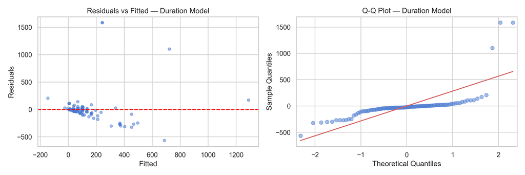

```python
if model_dur_py is not None:
    fig, axes = plt.subplots(1, 2, figsize=(12, 4))
    axes[0].scatter(model_dur_py.fittedvalues, model_dur_py.resid, alpha=0.5, s=20)
    axes[0].axhline(0, color="red", linestyle="--")
    axes[0].set_title("Residuals vs Fitted — Duration Model")
    axes[0].set_xlabel("Fitted"); axes[0].set_ylabel("Residuals")
    sm.qqplot(model_dur_py.resid, line="s", ax=axes[1], alpha=0.5)
    axes[1].set_title("Q-Q Plot — Duration Model")
    plt.tight_layout(); plt.show()
    print(f"Duration model — Adj. R²: {model_dur_py.rsquared_adj:.4f}")
```

[output not shown]

```python
if model_comp_py is not None:
    print(f"Compliance model — Adj. R²: {model_comp_py.rsquared_adj:.4f}")
```

```
Compliance model — Adj. R²: 0.3003
```

**Interpretation:** The duration model coefficients translate directly into proposal construction: each significant assessment type coefficient states how many additional days that engagement type takes relative to the reference category, all else equal. This is the number to embed in the project timeline template for each service line. The compliance score model is equally important: significant maturity level coefficients confirm whether our advisory pathway is delivering improvement, while a significant coefficient on `meetings` indicates whether client engagement intensity (measured by meeting frequency) is systematically associated with better compliance outcomes — validating a high-touch delivery model for complex clients. Any assessment type or delivery mode coefficient with a large absolute value and low p-value should immediately appear in the practice’s service design guidelines and standard proposal terms.

## References

- Adi, B. (2026). *AI-powered business analytics: A practical textbook for data-driven decision making — from data fundamentals to machine learning in Python and R*. Lagos Business School / markanalytics.online. https://markanalytics.online
- R Core Team. (2024). *R: A language and environment for statistical computing*. R Foundation for Statistical Computing.
- Wickham, H., & Grolemund, G. (2017). *R for Data Science*. O’Reilly Media.
- McKinney, W. (2022). *Python for Data Analysis* (3rd ed.). O’Reilly Media.
- Kassambara, A. (2024). *ggcorrplot: Visualization of a Correlation Matrix using ggplot2* (R package). CRAN.
- Pedersen, T. L. (2024). *patchwork: The Composer of Plots* (R package version 1.2.0). CRAN.
- Xie, Y. (2024). *knitr: A General-Purpose Package for Dynamic Report Generation in R* (R package). CRAN.

## Appendix: AI Usage Statement

GitHub Copilot (Microsoft) and ChatGPT (OpenAI) were used to accelerate document structuring, code templating in R and Python, and review of statistical workflow logic. All analytical decisions — technique selection, hypothesis formulation, regression model specification, and the interpretation of statistical outputs in terms of cybersecurity advisory practice operations — were independently validated by the author against the actual model outputs generated from the company’s project records. The operational recommendations regarding engagement risk-scoring, delivery mode guidelines, and maturity improvement contracting reflect the author’s independent professional judgement as Senior Manager and Head of Department at Digital Encode Limited.